# Pengaplikasian Fungsi RKU untuk Menangani Multikolinieritas

#### Deskripsi

Bangkitkan peubah $X_1$, $X_2$, $X_3$ sebanyak 1.000 amatan berdasarkan model regresi linear berganda berikut ini:

$$Y = 10 + 3X_1 + 5X_2 + 7X_3 + \varepsilon$$

dengan mengasumsikan bahwa $\varepsilon \sim N(\mu = 0, \sigma^2 = 30)$ dan antara peubah bebas terjadi **multikolinearitas**!

Kemudian hitung koefisien penduga parameter regresi komponen utama yang sudah ditransformasi balik menggunakan fungsi `RKU` yang sudah dibuat di nomor 2! (tidak ada batasan fungsi/*package* yang digunakan)

### Membangkitkan Data

Terdapat beberapa tahapan dalam melakukan pembangkitan data:

```r
library(car)
library(ggplot2)
library(GGally)
```

```r
# membuat fungsi untuk membangkitkan bilangan acak multivariate normal
# dengan korelasi tertentu
rmvn.eigen <- function(n, mu, Sigma) {
  d <- length(mu)
  ev <- eigen(Sigma, symmetric = TRUE)
  lambda <- ev$values
  V <- ev$vectors

  R <- V %*% diag(sqrt(lambda)) %*% t(V)
  Z <- matrix(rnorm(n*d), nrow = n, ncol = d)
  x <- Z %*% R + matrix(mu,n,d, byrow = T)

  return(x)
}
```

```r
# jumlah pengamatan
n <- 1000

# rataan peubah penjelas
mu <- c(0,0,0)

# matriks ragam-peragam
Sigma <- matrix(c(1,.95,.95,.95,1,.95,.95,.95,1), nrow = 3, ncol = 3)

# membangkitkan bilangan (X dan sisaan)
set.seed(5555)
x <- rmvn.eigen(n, mu, Sigma)
eps <- rnorm(n,0,sqrt(30))

colnames(x) <- paste0("X", seq(length(mu)))
```

```r
# menentukan beta, dan membangkitkan Y

beta <- c(b0 = 10, b1 = 3, b2 = 5, b3 = 7)
y <- round(beta[1] + (x %*% beta[-1]) + eps, 4)
```

### Pemeriksaan Korelasi Data yang Dibangkitkan

Selanjutnya memeriksa apakah bilangan yang dibangkitkan memiliki korelasi dan sebaran yang ditentukan.

```r
# matriks korelasi
cor(x)
```

```
##           X1        X2        X3
## X1 1.0000000 0.9519284 0.9474503
## X2 0.9519284 1.0000000 0.9487071
## X3 0.9474503 0.9487071 1.0000000
```

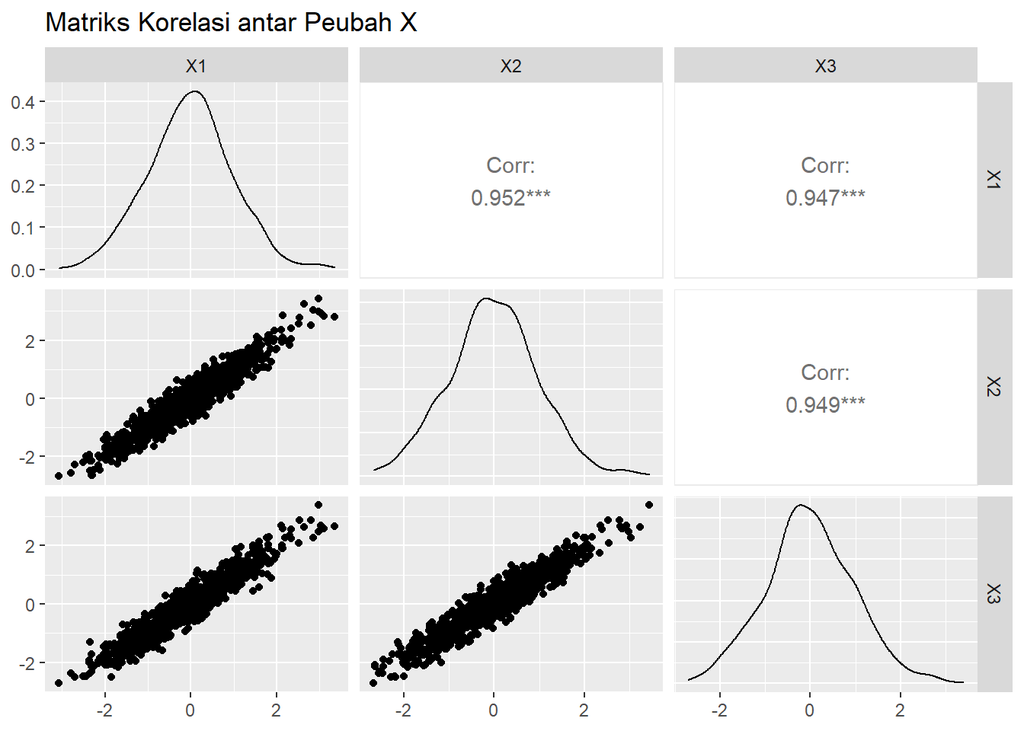

```r
# matriks plot
GGally::ggpairs(as.data.frame(x), title = "Matriks Korelasi antar Peubah X")
```

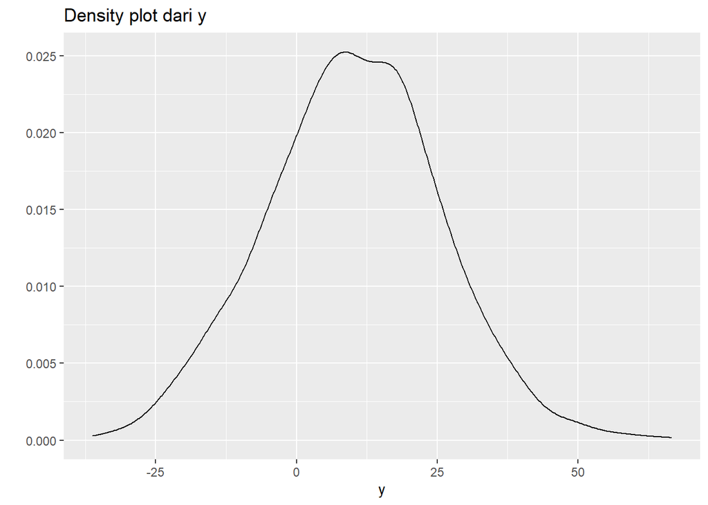

```r
# sebaran dari y
qplot(y, geom="density", main = "Density plot dari y")
```

Langkah selanjutnya dilakukan pemodelan regresi serta memeriksa apakah ada *multikolinieritas* dengan mengacu pada nilai VIF.

```r
dataRegresi <- data.frame(y, x)

# analisis regresi
reg <- lm(y ~., data = dataRegresi)
reg
```

```
##
## Call:
## lm(formula = y ~ ., data = dataRegresi)
##
## Coefficients:
## (Intercept)           X1           X2           X3
##      10.353        2.826        4.412        7.831
```

```r
# menghitung VIF
car::vif(reg)
```

```
##       X1       X2       X3
## 13.48527 13.80678 12.65924
```

Dari hasil pemeriksaan di atas diketahui bahwa data yang dibangkitkan sesuai dengan yang telah ditentukan. Yaitu mempunyai koefisien (kurang lebih) $b_0 = 10$, $b_1 = 3$, $b_2 = 5$, $b_3 = 7$, serta antar peubah X mempunyai korelasi (ditunjukkan oleh korelasi sekitar 0.95) sehingga terjadi multikolinieritas (semua VIF > 10). Untuk itu perlu penanganan khusus untuk mengatasi masalah ini. Salah satu metode yang dapat digunakan untuk mengatasi multikolinieritas adalah regresi komponen utama.

### Regresi Komponen Utama

Dengan menggunakan fungsi `RKU` yang sudah dibuat pada soal sebelumnya, kita dapat melakukan regresi komponen utama.

```r
# load script yang berisi fungsi RKU
source("https://raw.githubusercontent.com/nurandi/sta561-uts/main/r/rku.R", # local-file: "../r/rku.R"
       local = knitr::knit_global())
```

```r
# regresi komponen utama
# untuk ilustrasi, akan dipilih k=2, sehingga dapat dilihat korelasi antar peubah X
# beserta nilai VIF-nya
rku <- RKU(y = y, X = x, k = 2)
```

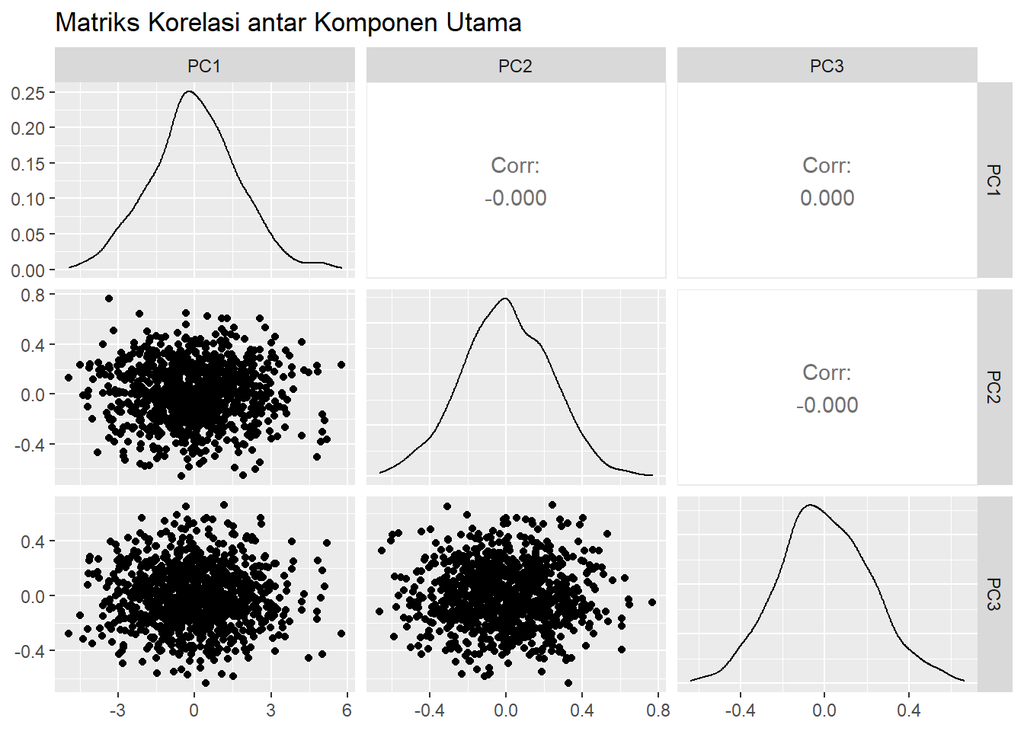

```r
# matriks plot dari skor komponen utama
GGally::ggpairs(as.data.frame(rku$pca$pc.score), title = "Matriks Korelasi antar Komponen Utama")
```

```r
# VIF hasil lm
car::vif(rku$pcr.lm)
```

```
## PC1 PC2
##   1   1
```

Dari plot korelasi di atas diketahui bahwa antar komponen utama tidak saling berkorelasi (koefisien nol). Demikian juga VIF hasil regresi komponen utama (dengan dua komponen) bernilai satu, sehingga tidak terjadi multikolinieritas.

Selanjutnya, fungsi generik `print` berikut menampilkan hasil analisis regresi komponen utama secara lebih lengkap.

```r
print(rku, mode = "ext")
```

```
## PRINCIPAL COMPONENT ANALYSIS
## Input:  1000 rows X 3 columns
##
## Eigenanalysis of Correlation Matrix:
##                  PC1        PC2        PC3
## Eigenvalue 2.8987251 0.05330414 0.04797075
## Proportion 0.9662417 0.01776805 0.01599025
## Cumulative 0.9662417 0.98400975 1.00000000
##
## Eigenvectors:
##          PC1        PC2        PC3
## X1 0.5774833 -0.5011934  0.6444518
## X2 0.5777377 -0.3068562 -0.7563455
## X3 0.5768294  0.8091010  0.1123539
##
## Score of Principal Component (Preview):
##              PC1         PC2         PC3
## [1,] -0.36186567  0.26397942 -0.01201767
## [2,] -1.59933158 -0.44662042 -0.30144303
## [3,] -2.77553645 -0.26510308 -0.35960828
## [4,]  0.05143958 -0.33233650 -0.11210667
## [5,]  1.19569507  0.12162430  0.22694838
## [6,] -1.91675913  0.02417343 -0.25730835
## ...
##
## PRINCIPAL COMPONENT REGRESSION
## With 2 Principal Component(s)
##
## Formula: y ~ Principal Component Score
##
##              Estimate Std. Error   t value     Pr(>|t|)
## (Intercept) 10.161056  0.1719591 59.089962 0.000000e+00
## PC1          8.554994  0.1010506 84.660498 0.000000e+00
## PC2          3.434382  0.7451812  4.608788 4.575357e-06
##
## R-squared:  0.8782014,  Adjusted R-squared:  0.877957
## F Statistics: 3594.32,  DF1: 2,  DF2: 997,  p-value: < 2.22e-16
##
## Inverse Transform into Z Score
##             Estimates
## (Intercept) 10.161056
## Z_X1         3.219076
## Z_X2         3.888680
## Z_X3         7.713534
##
## Inverse Transform into X
##             Estimates
## (Intercept) 10.356865
## X1           3.266871
## X2           3.900774
## X3           7.908617
```

Adapun persamaan regresi yang diperoleh adalah:

$$\hat{y} = 10.16 + 8.55PC_1 + 3.43PC_2$$
Yang dapat ditransformasi balik kedalam *z-score*

$$\hat{y} = 10.16 + 3.22Z_{X1} + 3.89Z_{X2} + 7.71Z_{X3}$$
Atau, jika ditransformasi balik ke peubah sebenarnya, diperoleh

$$\hat{y} = 10.36 + 3.27X_1 + 3.90X_2 + 7.91X_3$$